# Introducción a R

GUALAPURO, Moisés

2023-07-05

# Introducción

## Tipos de datos

### Vectores

Es una lista de elementos

```r
edades = c(21, 27, 21, 24, 23, 24)
edades[-1]
```

```
## [1] 27 21 24 23 24
```

### Listas

Conjunto de datos múltiples

```r
estudiantes = list(nombres = c("Michael", "Dayan"),
                   edades = c(21, 27))
estudiantes$edades[2]
```

```
## [1] 27
```

### Dataframe

Tabla de datos organizados en filas y columnas.

```r
estudiantes = data.frame(list(nombres = c("Michael", "Dayan"),
                   edades = c(21, 27)))
estudiantes$edades[2]
```

```
## [1] 27
```

# Data precargada en R

```r
head(InsectSprays,2)
```

```
##   count spray
## 1    10     A
## 2     7     A
```

**Exploración de los datos**: tipos de datos y estadísticas básicas.

```r
str(InsectSprays)
```

```
## 'data.frame':    72 obs. of  2 variables:
##  $ count: num  10 7 20 14 14 12 10 23 17 20 ...
##  $ spray: Factor w/ 6 levels "A","B","C","D",..: 1 1 1 1 1 1 1 1 1 1 ...
```

```r
summary(InsectSprays)
```

```
##      count       spray
##  Min.   : 0.00   A:12
##  1st Qu.: 3.00   B:12
##  Median : 7.00   C:12
##  Mean   : 9.50   D:12
##  3rd Qu.:14.25   E:12
##  Max.   :26.00   F:12
```

### Visualización exploratoria

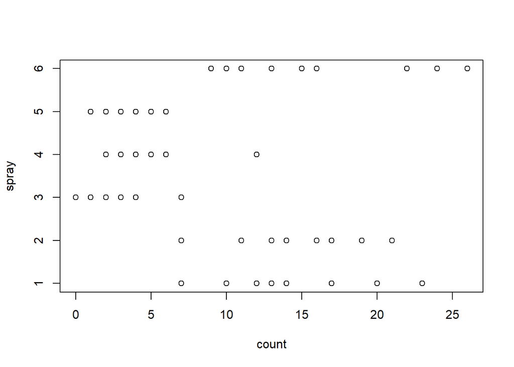

```r
plot(InsectSprays)
```

Se tiene seis grupos de insecticidas, donde la cantidad de insectos para los insectidass tipo A, B y F son mayores que las de tipo C, D, E. ## Análisis

$Ho:$ La cantidad de insectos en todos los tipos de insecticida son iguales.

$Ha:$ La cantidad de insectos en al menos uno de los tipos de insecticida es diferente.

```r
library(dplyr)
resumen = InsectSprays %>% group_by(spray) %>%
  summarise(mean = mean(count),
            sd = sd(count),
            n = n(),
            se = sd/sqrt(n))
resumen
```

```
## # A tibble: 6 × 5
##   spray  mean    sd     n    se
##   <fct> <dbl> <dbl> <int> <dbl>
## 1 A     14.5   4.72    12 1.36
## 2 B     15.3   4.27    12 1.23
## 3 C      2.08  1.98    12 0.570
## 4 D      4.92  2.50    12 0.723
## 5 E      3.5   1.73    12 0.5
## 6 F     16.7   6.21    12 1.79
```

### Prueba de hipóteisis (ANOVA)

```r
anova(lm(count ~ spray, data = InsectSprays))
```

```
## Analysis of Variance Table
##
## Response: count
##           Df Sum Sq Mean Sq F value    Pr(>F)
## spray      5 2668.8  533.77  34.702 < 2.2e-16 ***
## Residuals 66 1015.2   15.38
## ---
## Signif. codes:  0 '***' 0.001 '**' 0.01 '*' 0.05 '.' 0.1 ' ' 1
```

Con un 95% de confianza (p<0.05) al menos uno de los tipos de spray tiene un conteo diferente de insectos.

### Prueba posterior (hipótesis)

En esta parte se evalua qué categorías tienen diferencia.

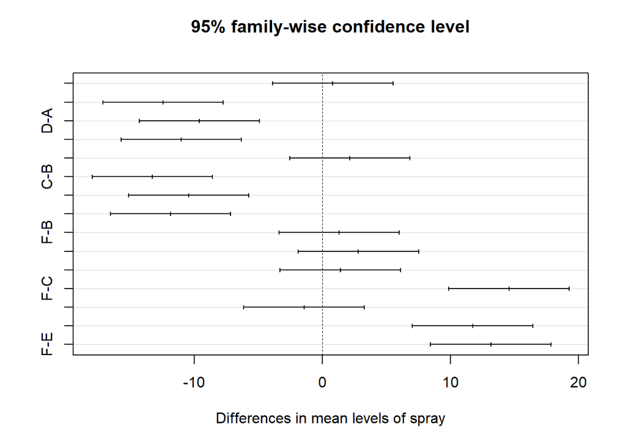

```r
aov1 = aov(count ~ spray, data = InsectSprays)

avoTk = TukeyHSD(aov1, "spray")
plot(avoTk)
```

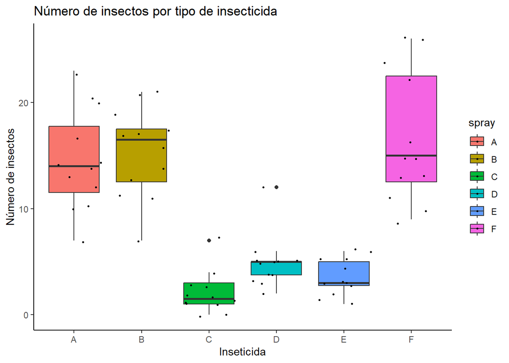

```r
library(ggplot2)
ggplot(InsectSprays, aes(x = spray, y = count, fill = spray)) +
  geom_boxplot() +
  geom_jitter(size = 0.5) +
  theme_classic() +
  labs(title = "Número de insectos por tipo de insecticida",
       x = "Inseticida",
       y = "Número de insectos")
```

Existe diferencia significativa entre las medidas del grupo de sprays A, B y F frente al grupo C, D y E.